# 利用邏輯迴歸分析航空業客戶忠誠度

黃大維，台灣大學統計碩士

2018年7月1日

## 資料輸入與前處理

首先，我們讀入兩個主要用來分析的資料集合。

```r
library("tidyverse")
setwd("~/Google 雲端硬碟/[Hahow] R 語言和商業分析課程/Part 2 - 資料科學核心方法/2-6 Logistic Regression/case")
internal.data <- read_csv("internal_data.csv")
internal.data$credit_card_vendor <- as.factor(internal.data$credit_card_vendor)
survey.data <- read_csv("survey_data.csv")
```

如果你想以表格形式output出結果，可以使用以下程式碼。

```r
head(internal.data, 5)
```

```
## # A tibble: 5 x 7
##   user_id    dm_message dm_post dm_email credit_card_ven… credit_card_bon…
##   <chr>           <int>   <int>    <int> <fct>                       <int>
## 1 6cfe0e612…          0       0        0 Vendor B                        1
## 2 c51ce410c…          1       1        1 Vendor B                        3
## 3 86b122d43…          1       1        1 Vendor B                        1
## 4 0353ab4cb…          0       0        0 Vendor B                        2
## 5 ebd9629fc…          1       0        1 Vendor C                        2
## # ... with 1 more variable: coupon <dbl>
```

```r
head(survey.data, 5)
```

```
## # A tibble: 5 x 15
##   user_id           is_loyal depart_on_time arrive_on_time register_method
##   <chr>                <int>          <int>          <int> <chr>
## 1 c8c41c4a18675a74…        0              1              1 others
## 2 9f396fe44e7c05c1…        0              1              1 others
## 3 9778d5d219c5080b…        1              1              1 website
## 4 0ff8033cf9437c21…        1              1              1 others
## 5 fb89705ae6d743bf…        0              1              1 others
## # ... with 10 more variables: register_rate <int>, class <int>,
## #   seat_rate <int>, meal_rate <int>, flight_rate <int>,
## #   package_rate <int>, tv_ad <int>, youtube_ad_1 <int>,
## #   youtube_ad_2 <int>, youtube_ad_3 <int>
```

```r
complete.data <- merge(survey.data, internal.data,
                       by = "user_id")
head(complete.data, 5)
```

```
##                            user_id is_loyal depart_on_time arrive_on_time
## 1 00411460f7c92d2124a67ea0f4cb5f85        1              1              1
## 2 006f52e9102a8d3be2fe5614f42ba989        1              0              0
## 3 00ac8ed3b4327bdd4ebbebcb2ba10a00        0              1              1
## 4 00ec53c4682d36f5c4359f4ae7bd7ba1        0              0              0
## 5 01161aaa0b6d1345dd8fe4e481144d84        1              1              1
##   register_method register_rate class seat_rate meal_rate flight_rate
## 1           phone             3     3         3         3           3
## 2      mobile_app             2     2         4         4           2
## 3          others             4     3         1         3           2
## 4          others             3     3         1         2           2
## 5           phone             4     2         4         4           5
##   package_rate tv_ad youtube_ad_1 youtube_ad_2 youtube_ad_3 dm_message
## 1            3     1            0            1            0          0
## 2            4     1            0            0            0          1
## 3            2     0            1            1            1          1
## 4            3     1            1            1            1          1
## 5            3     1            0            0            1          1
##   dm_post dm_email credit_card_vendor credit_card_bonus coupon
## 1       0        0           Vendor A                 2  196.7
## 2       1        0           Vendor A                 3   53.6
## 3       0        1           Vendor C                 1  107.8
## 4       0        1           Vendor B                 2   37.5
## 5       0        0           Vendor B                 1   43.3
```

```r
complete.data$user_id <- as.character(complete.data $user_id)
complete.data$credit_card_bonus <- as.factor(complete.data$credit_card_bonus)
complete.data$register_method <- as.factor(complete.data $register_method)
complete.data$class <- as.factor(complete.data$class)
```

```r
# install.packages("dummies")
library(dummies)
complete.data.new <- dummy.data.frame(complete.data,
                                      sep = "_",
                                      dummy.classes = 'factor')
head(complete.data.new, 5)
```

```
##                            user_id is_loyal depart_on_time arrive_on_time
## 1 00411460f7c92d2124a67ea0f4cb5f85        1              1              1
## 2 006f52e9102a8d3be2fe5614f42ba989        1              0              0
## 3 00ac8ed3b4327bdd4ebbebcb2ba10a00        0              1              1
## 4 00ec53c4682d36f5c4359f4ae7bd7ba1        0              0              0
## 5 01161aaa0b6d1345dd8fe4e481144d84        1              1              1
##   register_method_mobile_app register_method_others register_method_phone
## 1                          0                      0                     1
## 2                          1                      0                     0
## 3                          0                      1                     0
## 4                          0                      1                     0
## 5                          0                      0                     1
##   register_method_website register_rate class_1 class_2 class_3 seat_rate
## 1                       0             3       0       0       1         3
## 2                       0             2       0       1       0         4
```

[output cut: 33 more lines]

## 資料探索

為了瞭解變數間比次的相關程度，我們會利用 `cor` 函數計算變數彼此間的相關係數。

```r
cor(complete.data.new[, 2:ncol(complete.data.new)])[1:5, 1:5]
```

```
##                               is_loyal depart_on_time arrive_on_time
## is_loyal                    1.00000000     0.29650154    0.290173607
## depart_on_time              0.29650154     1.00000000    0.790602740
## arrive_on_time              0.29017361     0.79060274    1.000000000
## register_method_mobile_app  0.05958308     0.03516997    0.001102798
## register_method_others     -0.18670548    -0.04494452   -0.020169354
##                            register_method_mobile_app
## is_loyal                                  0.059583082
## depart_on_time                            0.035169975
## arrive_on_time                            0.001102798
## register_method_mobile_app                1.000000000
## register_method_others                   -0.405408696
##                            register_method_others
## is_loyal                              -0.18670548
## depart_on_time                        -0.04494452
## arrive_on_time                        -0.02016935
## register_method_mobile_app            -0.40540870
## register_method_others                 1.00000000
```

我通常喜歡使用熱圖 (heatmap) 視覺化變數間的相關程度，如果要使用 ggplot2 繪製相關係數的熱圖，必須先將資料整理成「變數 1 - 變數 2 - 相關係數」的 data frame，我們可以利用 `reshape2`套件中的`melt`函數輕鬆把矩陣格式轉換成上述的 data frame。

```r
library(reshape2)
head(melt(cor(complete.data.new[, 2:ncol(complete.data.new)])), 5)
```

```
##                         Var1     Var2       value
## 1                   is_loyal is_loyal  1.00000000
## 2             depart_on_time is_loyal  0.29650154
## 3             arrive_on_time is_loyal  0.29017361
## 4 register_method_mobile_app is_loyal  0.05958308
## 5     register_method_others is_loyal -0.18670548
```

接著我們就可以用`geom_tile`(繪製方形圖)繪製相關係數的熱圖囉！

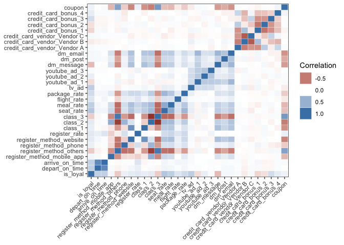

```r
ggplot(melt(cor(complete.data.new[, 2:ncol(complete.data.new)])),
       aes(Var1, Var2)) +
  geom_tile(aes(fill = value), colour = "white") +
  scale_fill_gradient2(low = "firebrick4", high = "steelblue",
                       mid = "white", midpoint = 0) +
  guides(fill=guide_legend(title="Correlation")) +
  theme_bw() +
  theme(axis.text.x = element_text(angle = 45, hjust = 1, vjust = 1),
        axis.title = element_blank())
```

## 資料建模與分析

### 1. 考量「行銷因素」的邏輯迴規模型

首先，我們先建立只考量「行銷因素」的邏輯迴歸模型。在 R 語言中，我習慣使用內建的 `glm` 函數 (glm = generalized linear model)，主要要填入的參數有：

- 模型公式：假設你的想建立的邏輯迴歸模型反應變數為 $Y$，解釋變數為 $X_1$ 與 $X_2$，可以輸入 `Y ~ X1 + X2`。
- 資料集合：輸入 `data = dataset.name` 即可，記得變數的名稱要與模型公式中的名稱完全符合。
- 模型種類：由於 `glm` 不只適用於邏輯回歸，如果你希望建立邏輯迴歸模型，請使用 `family = binomial(link="logit")`。

```r
# Build logistic regression model
marketing.model <- glm(is_loyal ~ dm_message + dm_post + dm_email +
                         credit_card_vendor + credit_card_bonus +
                         tv_ad + youtube_ad_1 + youtube_ad_2 + youtube_ad_3,
                       data = complete.data, family = binomial(link="logit"))
```

我們可以使用 `summary` 函數輸出各個變數的係數估計與 p-值：

- 對客戶忠誠度有顯著正面影響 ($\alpha = 0.05$) 的變數：  
  dm_post, dm_email, credit_card_bonus3, credit_card_bonus4, tv_ad, youtube_ad_2
- 對客戶忠誠度有顯著負面影響 ($\alpha = 0.05$) 的變數：  
  dm_message, youtube_ad_1

問題：這個模型可以完整解釋客戶的忠誠與否嗎？（答：顯然不行，缺少重要面向。）

```r
# Summarize coefficients and p-values
summary(marketing.model)
```

```
##
## Call:
## glm(formula = is_loyal ~ dm_message + dm_post + dm_email + credit_card_vendor +
##     credit_card_bonus + tv_ad + youtube_ad_1 + youtube_ad_2 +
##     youtube_ad_3, family = binomial(link = "logit"), data = complete.data)
##
## Deviance Residuals:
##     Min       1Q   Median       3Q      Max
## -2.7937  -0.9722   0.3450   0.6746   2.4260
##
## Coefficients:
##                            Estimate Std. Error z value Pr(>|z|)
## (Intercept)                -0.29479    0.27283  -1.081  0.27992
## dm_message                 -2.48836    0.25464  -9.772  < 2e-16 ***
## dm_post                     0.81066    0.24804   3.268  0.00108 **
## dm_email                    1.58700    0.23919   6.635 3.25e-11 ***
## credit_card_vendorVendor B -0.10535    0.24513  -0.430  0.66736
## credit_card_vendorVendor C -0.15461    0.24607  -0.628  0.52980
## credit_card_bonus2          0.24767    0.20734   1.194  0.23228
## credit_card_bonus3          1.85538    0.25451   7.290 3.10e-13 ***
## credit_card_bonus4          1.72444    0.37384   4.613 3.97e-06 ***
## tv_ad                       2.41823    0.22508  10.744  < 2e-16 ***
## youtube_ad_1               -1.64161    0.22992  -7.140 9.34e-13 ***
## youtube_ad_2                0.63570    0.22153   2.870  0.00411 **
## youtube_ad_3                0.05778    0.21398   0.270  0.78713
## ---
## Signif. codes:  0 '***' 0.001 '**' 0.01 '*' 0.05 '.' 0.1 ' ' 1
##
## (Dispersion parameter for binomial family taken to be 1)
##
##     Null deviance: 1316.84  on 999  degrees of freedom
## Residual deviance:  939.78  on 987  degrees of freedom
## AIC: 965.78
##
## Number of Fisher Scoring iterations: 5
```

接下來，我們利用 `predict(model, data, type)` 函數得到模型估計的$\mathbb{P}(Y=1 | X_1,\cdots,X_p)$：

- `type = "response"`：得到每一個個體的機率。
- `type = "term"`：得到每一個個體 $\beta_i\cdot X_i$ 的數值。

```r
predict.prob <- predict(marketing.model, complete.data, type = "response")
```

接下來，利用 `InformationValue` 套件中的函式，可已得到使分類誤差最小的 cutoff probability，以及計算常用的分類好壞指標：

```r
# install.packages("InformationValue")
library("InformationValue")

# Calculate cut-off probability minimizing the miscalssification error
opt.cutoff <- optimalCutoff(complete.data$is_loyal, predict.prob)[1]

# Calculate Important Assessment Measure
confusionMatrix(complete.data$is_loyal, predict.prob, threshold = opt.cutoff)
```

```
##     0   1
## 0 283 133
## 1  86 498
```

```r
misClassError(complete.data$is_loyal, predict.prob, threshold = opt.cutoff)
```

```
## [1] 0.219
```

```r
precision(complete.data$is_loyal, predict.prob, threshold = opt.cutoff)
```

```
## [1] 0.8527397
```

```r
sensitivity(complete.data$is_loyal, predict.prob, threshold = opt.cutoff)
```

```
## [1] 0.7892235
```

```r
specificity(complete.data$is_loyal, predict.prob, threshold = opt.cutoff)
```

```
## [1] 0.7669377
```

最後，我喜歡利用 `plotROC` 套件繪製分類模型的 ROC 曲線，並計算 AUC (Area Under Curve)。模型的 AUC 為 0.837，分類的準確度還算不錯。

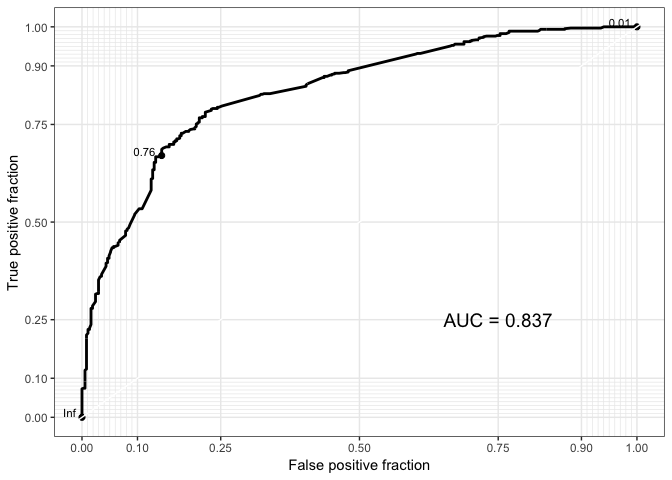

```r
# devtools::install_github("sachsmc/plotROC")
library("plotROC")

predict.table <- data.frame(true_label = complete.data$is_loyal,
                            predict_prob = predict.prob)

# Plot ROC curve and calculate AUC
basic.plot <- ggplot(predict.table, aes(d = true_label, m = predict.prob)) +
  geom_roc(n.cuts = 3, labelsize = 3, labelround = 2)
basic.plot + style_roc() +
  annotate("text", x = .75, y = .25, size = 5,
           label = paste("AUC =", round(calc_auc(basic.plot)$AUC, 3)))
```

### 2. 考量「服務品質因素」的邏輯迴規模型

接著我們建立的是單純只考量「服務品質」的邏輯回歸模型，跟前一個模型比較起來，AIC 稍微高了些，代表行銷活動對於客戶忠誠與否還是相當有影響力的。我們可以使用 `summary` 函數輸出各個變數的係數估計與 p-值：

```r
service.model <- glm(is_loyal ~
                       depart_on_time + arrive_on_time +
                       register_method + register_rate +
                       class + seat_rate + meal_rate +
                       flight_rate + package_rate,
                     data=complete.data, family=binomial(link="logit"))
summary(service.model)
```

```
##
## Call:
## glm(formula = is_loyal ~ depart_on_time + arrive_on_time + register_method +
##     register_rate + class + seat_rate + meal_rate + flight_rate +
##     package_rate, family = binomial(link = "logit"), data = complete.data)
##
## Deviance Residuals:
##     Min       1Q   Median       3Q      Max
## -2.4613  -0.9064   0.4798   0.8034   2.1012
##
## Coefficients:
##                        Estimate Std. Error z value Pr(>|z|)
## (Intercept)            -5.42319    0.79462  -6.825 8.80e-12 ***
## depart_on_time          0.93815    0.27738   3.382 0.000719 ***
## arrive_on_time          0.73678    0.25268   2.916 0.003547 **
## register_methodothers  -0.22403    0.56022  -0.400 0.689232
## register_methodphone    0.26003    0.37134   0.700 0.483776
## register_methodwebsite  0.01901    0.42801   0.044 0.964568
## register_rate          -0.09110    0.07102  -1.283 0.199572
## class2                 -0.23484    0.47661  -0.493 0.622201
## class3                  0.79733    0.70147   1.137 0.255684
## seat_rate               0.79906    0.11753   6.799 1.05e-11 ***
## meal_rate               0.61652    0.12822   4.808 1.52e-06 ***
## flight_rate             0.21218    0.07225   2.937 0.003317 **
## package_rate            0.18122    0.10661   1.700 0.089161 .
## ---
## Signif. codes:  0 '***' 0.001 '**' 0.01 '*' 0.05 '.' 0.1 ' ' 1
##
## (Dispersion parameter for binomial family taken to be 1)
##
##     Null deviance: 1316.8  on 999  degrees of freedom
## Residual deviance: 1048.5  on 987  degrees of freedom
## AIC: 1074.5
##
## Number of Fisher Scoring iterations: 4
```

接下來我們可以看到，除了分類正確率表現得較差外，specificity 表現的遠不如前一個模型，代表沒考量行銷活動的話，必較沒有辦法正確區分 negative cases。

```r
predict.prob <- predict(service.model, complete.data, type="response")
opt.cutoff <- optimalCutoff(complete.data$is_loyal, predict.prob)[1]
misClassError(complete.data$is_loyal, predict.prob, threshold = opt.cutoff)
```

```
## [1] 0.247
```

```r
precision(complete.data$is_loyal, predict.prob, threshold = opt.cutoff)
```

```
## [1] 0.7815249
```

```r
sensitivity(complete.data$is_loyal, predict.prob, threshold = opt.cutoff)
```

```
## [1] 0.844691
```

```r
specificity(complete.data$is_loyal, predict.prob, threshold = opt.cutoff)
```

```
## [1] 0.596206
```

最後從 ROC 曲線與 AUC 也可以知道只考量服務品質的模型不如只考量行銷活動的模型，代表航空公司的行銷確實有所作用。

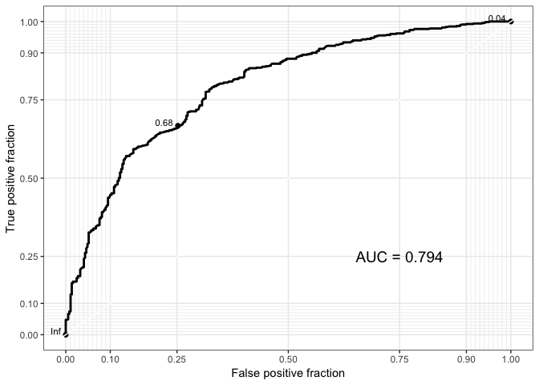

```r
predict.table <- data.frame(true_label = complete.data$is_loyal,
                            predict_prob = predict.prob)

# Plot ROC curve and calculate AUC
basic.plot <- ggplot(predict.table, aes(d = true_label, m = predict.prob)) +
  geom_roc(n.cuts = 3, labelsize = 3, labelround = 2)
basic.plot + style_roc() +
  annotate("text", x = .75, y = .25, size = 5,
           label = paste("AUC =", round(calc_auc(basic.plot)$AUC, 3)))
```

### 3. 包含「行銷活動」與「服務品質」

接下來，我們納入所有解釋變數建立邏輯迴歸模型進行分析。

```r
full.model <- glm(is_loyal ~ depart_on_time + arrive_on_time +
                    register_method + register_rate +
                    class + seat_rate + meal_rate +
                    flight_rate + package_rate +
                    dm_message + dm_post + dm_email +
                    credit_card_vendor + credit_card_bonus +
                    tv_ad + youtube_ad_1 + youtube_ad_2 + youtube_ad_3,
                  data = complete.data,
                  family = binomial(link="logit"))

summary(full.model)
```

```
##
## Call:
## glm(formula = is_loyal ~ depart_on_time + arrive_on_time + register_method +
##     register_rate + class + seat_rate + meal_rate + flight_rate +
##     package_rate + dm_message + dm_post + dm_email + credit_card_vendor +
##     credit_card_bonus + tv_ad + youtube_ad_1 + youtube_ad_2 +
##     youtube_ad_3, family = binomial(link = "logit"), data = complete.data)
##
## Deviance Residuals:
##      Min        1Q    Median        3Q       Max
## -2.81132  -0.12895   0.01873   0.20317   2.54677
##
## Coefficients:
##                            Estimate Std. Error z value Pr(>|z|)
## (Intercept)                -6.77996    1.53787  -4.409 1.04e-05 ***
## depart_on_time              3.47290    0.52029   6.675 2.47e-11 ***
## arrive_on_time              1.45559    0.42684   3.410 0.000649 ***
## register_methodothers      -0.33414    1.00121  -0.334 0.738580
## register_methodphone        1.23182    0.74367   1.656 0.097639 .
## register_methodwebsite      0.77613    0.78374   0.990 0.322030
## register_rate               0.01606    0.11795   0.136 0.891689
## class2                     -3.91880    0.87045  -4.502 6.73e-06 ***
## class3                     -6.20327    1.40603  -4.412 1.02e-05 ***
## seat_rate                   2.26388    0.24699   9.166  < 2e-16 ***
## meal_rate                   1.01093    0.21901   4.616 3.91e-06 ***
## flight_rate                 0.57915    0.12229   4.736 2.18e-06 ***
## package_rate               -0.19984    0.17361  -1.151 0.249708
## dm_message                 -9.56975    0.86379 -11.079  < 2e-16 ***
## dm_post                    -0.30074    0.43935  -0.685 0.493648
## dm_email                    0.19997    0.45116   0.443 0.657599
## credit_card_vendorVendor B -0.31503    0.40734  -0.773 0.439300
## credit_card_vendorVendor C -0.14248    0.40447  -0.352 0.724630
## credit_card_bonus2          0.44029    0.33066   1.332 0.183012
## credit_card_bonus3          4.14242    0.46123   8.981  < 2e-16 ***
## credit_card_bonus4          4.52876    0.70641   6.411 1.45e-10 ***
## tv_ad                       5.07518    0.47454  10.695  < 2e-16 ***
## youtube_ad_1               -0.52945    0.40879  -1.295 0.195261
## youtube_ad_2                0.88735    0.35434   2.504 0.012271 *
## youtube_ad_3                0.10095    0.34679   0.291 0.770979
## ---
## Signif. codes:  0 '***' 0.001 '**' 0.01 '*' 0.05 '.' 0.1 ' ' 1
##
## (Dispersion parameter for binomial family taken to be 1)
##
##     Null deviance: 1316.84  on 999  degrees of freedom
## Residual deviance:  418.63  on 975  degrees of freedom
## AIC: 468.63
##
## Number of Fisher Scoring iterations: 8
```

從各項分類指標來看，模型 3 在分類表現較模型 1 與模型 2 好。

```r
predict.prob <- predict(full.model, complete.data, type="response")

opt.cutoff <- optimalCutoff(complete.data$is_loyal, predict.prob)[1]

misClassError(complete.data$is_loyal, predict.prob, threshold = opt.cutoff)
```

```
## [1] 0.095
```

```r
confusionMatrix(complete.data$is_loyal, predict.prob, threshold = opt.cutoff)
```

```
##     0   1
## 0 307  33
## 1  62 598
```

```r
sensitivity(complete.data$is_loyal, predict.prob, threshold = opt.cutoff)
```

```
## [1] 0.9477021
```

```r
specificity(complete.data$is_loyal, predict.prob, threshold = opt.cutoff)
```

```
## [1] 0.8319783
```

模型 3 的 $AUC = 0.971$，代表分類表現非常佳，有較強的區分能力。

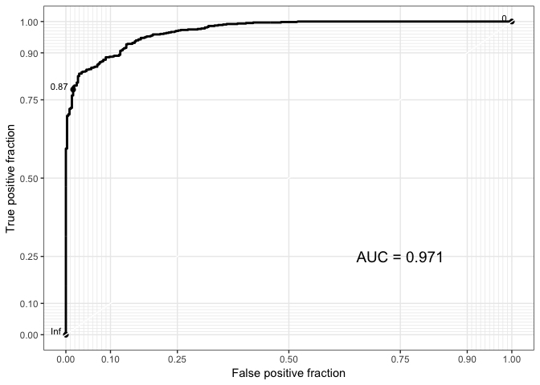

```r
predict.table <- data.frame(true_label = complete.data$is_loyal,
                            predict_prob = predict.prob)

# Plot ROC curve and calculate AUC
basic.plot <- ggplot(predict.table, aes(d = true_label, m = predict.prob)) +
  geom_roc(n.cuts = 3, labelsize = 3, labelround = 2)
basic.plot + style_roc() +
  annotate("text", x = .75, y = .25, size = 5,
           label = paste("AUC =", round(calc_auc(basic.plot)$AUC, 3)))
```

## 製作與主管報告的圖表

通常在建立完模型後，我會花一些時間製作能夠讓人一看就明白的圖表，協助非相關背景的同事們了解模型到底說明了什麼。˙

### 0. 視覺化「邏輯迴歸」的結果

由於行銷變數都是 0 / 1 的虛擬變數 (dummy variable)，scale 是一致的，所以我們可以直接比較邏輯迴歸中細述的大小，而係數大小代表的是「每個變數對於客戶忠誠度 odds 的影響程度」。

我喜歡用橫向的 Bar Chart 去視覺化迴歸係數，大家可以參考以下程式碼。值得注意的是，DM 相關的行銷策略表現在「同時考量服務品質與行銷策略」的模型 3 中時在表現得太差，所以我並不一定會真得呈現這個結果，或是會用稍微委婉的方式去說明這個結果。

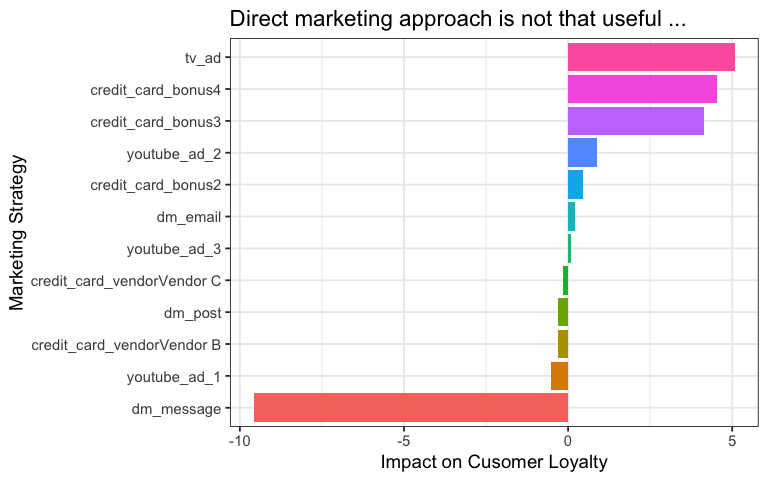

```r
# Get the coefficient table
summary.table <- data.frame(var_name = names(coefficients(full.model)),
                            coefficient = coefficients(full.model))

# Filter marketing-related variables
summary.table <- summary.table %>%
  filter(var_name %in% names(coefficients(marketing.model)) &
           var_name != "(Intercept)")

# Sort the table by the size of coefficients
summary.table <- summary.table[sort(summary.table$coefficient, index.return = T)$ix, ]

# Set correct variable type
summary.table$var_name <- factor(summary.table$var_name,
                                 levels = summary.table$var_name)

# Visualize the bar chart
ggplot(data = summary.table,
       aes(x = var_name, y = coefficient)) +
  geom_bar(aes(fill = var_name),
           position = "dodge",
           stat = "identity",
           show.legend = FALSE) +
  theme_bw(base_size = 14) +
  labs(title = "Direct marketing approach is not that useful ...",
       x = "Marketing Strategy", y = "Impact on Cusomer Loyalty") +
  coord_flip()
```

實際上在報告時，我更可能放的圖是「模型 1」的結果，一來是與「模型 3」的結果並沒有差太大，二來是仍然一些不顯著但仍然有正面效果的行銷策略看起來仍然是重要的。

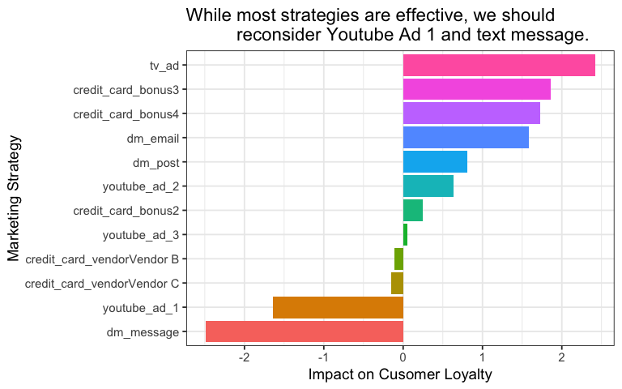

```r
# Get the coefficient table
summary.table <- data.frame(var_name = names(coefficients(marketing.model)),
                            coefficient = coefficients(marketing.model))
summary.table <- summary.table %>%
  filter(var_name != "(Intercept)")

# Sort the table by the size of coefficients
summary.table <- summary.table[sort(summary.table$coefficient, index.return = T)$ix, ]

# Set correct variable type
summary.table$var_name <- factor(summary.table$var_name,
                                 levels = summary.table$var_name)

# Visualize the bar chart
ggplot(data = summary.table,
       aes(x = var_name, y = coefficient)) +
  geom_bar(aes(fill = var_name),
           position = "dodge",
           stat = "identity",
           show.legend = FALSE) +
  theme_bw(base_size = 14) +
  labs(title = "While most strategies are effective, we should
          reconsider Youtube Ad 1 and text message.",
       x = "Marketing Strategy", y = "Impact on Cusomer Loyalty") +
  coord_flip()
```

### 1. 針對「客戶行銷部經理」

針對客戶行銷部分，最緊急的問題應該是 `dm_message` 會影發客戶的反感，但也有可能是再進行問卷時的 selection bias，需要更仔細的釐清問題。

我喜歡用 Bar Chart 去呈現不同組別的情況（如果組別數太多的話就會使用 Line Chart），從這張圖可以清楚說明：其他行銷成效是有用的，但 `dm_message` 卻造成忠誠客戶的比率降低。

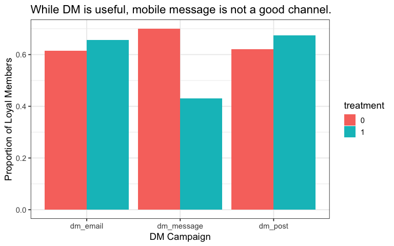

```r
# Get the summary table for dm strategies
var.names <- c("dm_post", "dm_email", "dm_message")
summary.table <- complete.data %>%
    group_by_(treatment = var.names[1]) %>%
    summarize(num_member = length(user_id),
              num_loyal = sum(is_loyal))
summary.table$var_name <- var.names[1]
for(i in 2:3){
  temp <- complete.data %>%
    group_by_(treatment = var.names[i]) %>%
    summarize(num_member = length(user_id),
              num_loyal = sum(is_loyal))
  temp$var_name <- var.names[i]
  summary.table <- rbind(summary.table, temp)
}
summary.table$proportion <- summary.table$num_loyal / summary.table$num_member

# Set the correct variavle type
summary.table$treatment <- as.factor(summary.table$treatment)
summary.table$var_name <- as.factor(summary.table$var_name)

# Plot the result
ggplot(data = summary.table,
       aes(x = var_name, y = proportion)) +
  geom_bar(aes(fill = treatment),
           position = "dodge",
           stat = "identity") +
  theme_bw(base_size = 14) +
  labs(x = "DM Campaign", y = "Proportion of Loyal Members",
       title = "While DM is useful, mobile message is not a good channel.")
```

### 2. 針對「外部合作部經理」

針對外部合作經理的假說「容易受信用卡里程紅利影響，應找尋適當的信用卡公司合作」，的確是容易受信用卡紅利影響，但是跟是哪一個信用卡公司並沒有特別大的關聯。

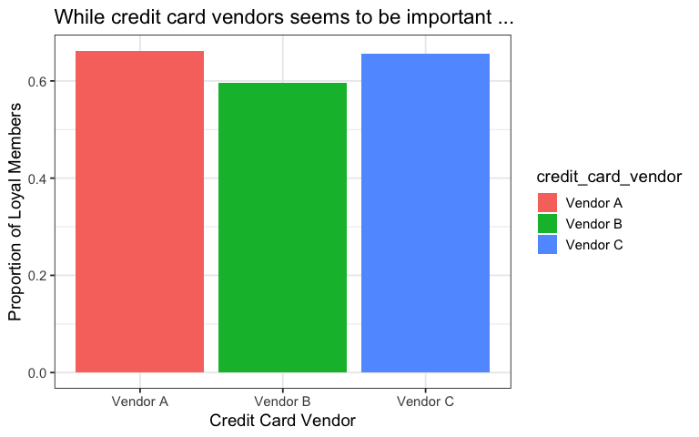

```r
# Get the summary table for credit card vendors
summary.table <- complete.data %>%
  group_by(credit_card_vendor) %>%
  summarize(num_member = length(user_id),
            num_loyal = sum(is_loyal))
summary.table$proportion <- summary.table$num_loyal / summary.table$num_member

# Visualize the result
ggplot(data = summary.table, aes(x = credit_card_vendor, y = proportion)) +
  geom_bar(aes(fill = credit_card_vendor), position = "dodge", stat = "identity") +
  theme_bw(base_size = 14) +
  labs(x = "Credit Card Vendor", y = "Proportion of Loyal Members",
       title = "While credit card vendors seems to be important ...")
```

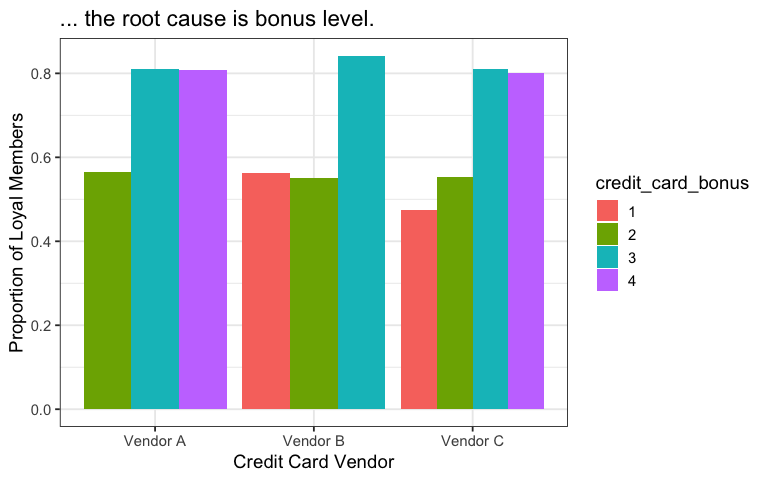

```r
# Get the summary table for credit card vendors and bonus levels
summary.table <- complete.data %>%
  group_by(credit_card_vendor, credit_card_bonus) %>%
  summarize(num_member = length(user_id),
            num_loyal = sum(is_loyal))
summary.table$proportion <- summary.table$num_loyal / summary.table$num_member

# Set correct data type
summary.table$credit_card_bonus <- as.factor(summary.table$credit_card_bonus)

# Visualize the result
ggplot(data = summary.table, aes(x = credit_card_vendor, y = proportion)) +
  geom_bar(aes(fill = credit_card_bonus), position = "dodge", stat = "identity") +
  theme_bw(base_size = 14) +
  labs(x = "Credit Card Vendor", y = "Proportion of Loyal Members",
       title = "... the root cause is bonus level.")
```

### 3. 針對「品牌形象部經理」

儘管大部分的品牌形象廣告都有正面影響，但我們可以特別注意：

- TV AD 表現非常傑出
- Youtube Ad 1 有負面影響

所以我會在圖表 title 中特別強調這兩個事件。

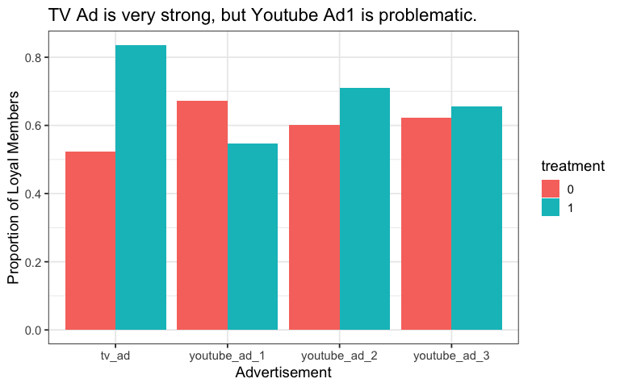

```r
# Get the summary table for dm strategies
var.names <- c("tv_ad", "youtube_ad_1", "youtube_ad_2", "youtube_ad_3")
summary.table <- complete.data %>%
    group_by_(treatment = var.names[1]) %>%
    summarize(num_member = length(user_id),
              num_loyal = sum(is_loyal))
summary.table$var_name <- var.names[1]
for(i in 2:4){
  temp <- complete.data %>%
    group_by_(treatment = var.names[i]) %>%
    summarize(num_member = length(user_id),
              num_loyal = sum(is_loyal))
  temp$var_name <- var.names[i]
  summary.table <- rbind(summary.table, temp)
}
summary.table$proportion <- summary.table$num_loyal / summary.table$num_member

# Set the correct variavle type
summary.table$treatment <- as.factor(summary.table$treatment)
summary.table$var_name <- as.factor(summary.table$var_name)

# Plot the result
ggplot(data = summary.table,
       aes(x = var_name, y = proportion)) +
  geom_bar(aes(fill = treatment),
           position = "dodge",
           stat = "identity") +
  theme_bw(base_size = 14) +
  labs(x = "Advertisement", y = "Proportion of Loyal Members",
       title = "TV Ad is very strong, but Youtube Ad1 is problematic.")
```